# Red Wine Analysis by Swetha Ganapathi Raman

### Introduction

The red wine dataset contains observations of 1,599 red wines with 11 variables on the chemical properties of the wine. Atleast 3 wines experts rated the quality of each wine, providing a rating between 0 (very bad) and 10 (very good).

The variables in the dataset are as below.

Input variables (based on physicochemical tests):

- 1 - fixed acidity (tartaric acid - g / dm^3)
- 2 - volatile acidity (acetic acid - g / dm^3)
- 3 - citric acid (g / dm^3)
- 4 - residual sugar (g / dm^3)
- 5 - chlorides (sodium chloride - g / dm^3
- 6 - free sulfur dioxide (mg / dm^3)
- 7 - total sulfur dioxide (mg / dm^3)
- 8 - density (g / cm^3)
- 9 - pH
- 10 - sulphates (potassium sulphate - g / dm3)
- 11 - alcohol (% by volume)

Output variable (based on sensory data):

- 12 - quality (score between 0 and 10)

The objective of this Exploratory data analysis is to analyze the variables and determine which of the chemical properties of the wine influence its quality the most.

### Summary of the dataset

```
## [1] 1599   13
```

```
## 'data.frame':    1599 obs. of  13 variables:
##  $ X                   : int  1 2 3 4 5 6 7 8 9 10 ...
##  $ fixed.acidity       : num  7.4 7.8 7.8 11.2 7.4 7.4 7.9 7.3 7.8 7.5 ...
##  $ volatile.acidity    : num  0.7 0.88 0.76 0.28 0.7 0.66 0.6 0.65 0.58 0.5 ...
##  $ citric.acid         : num  0 0 0.04 0.56 0 0 0.06 0 0.02 0.36 ...
##  $ residual.sugar      : num  1.9 2.6 2.3 1.9 1.9 1.8 1.6 1.2 2 6.1 ...
##  $ chlorides           : num  0.076 0.098 0.092 0.075 0.076 0.075 0.069 0.065 0.073 0.071 ...
##  $ free.sulfur.dioxide : num  11 25 15 17 11 13 15 15 9 17 ...
##  $ total.sulfur.dioxide: num  34 67 54 60 34 40 59 21 18 102 ...
##  $ density             : num  0.998 0.997 0.997 0.998 0.998 ...
##  $ pH                  : num  3.51 3.2 3.26 3.16 3.51 3.51 3.3 3.39 3.36 3.35 ...
##  $ sulphates           : num  0.56 0.68 0.65 0.58 0.56 0.56 0.46 0.47 0.57 0.8 ...
##  $ alcohol             : num  9.4 9.8 9.8 9.8 9.4 9.4 9.4 10 9.5 10.5 ...
##  $ quality             : int  5 5 5 6 5 5 5 7 7 5 ...
```

```
##        X          fixed.acidity   volatile.acidity  citric.acid
##  Min.   :   1.0   Min.   : 4.60   Min.   :0.1200   Min.   :0.000
##  1st Qu.: 400.5   1st Qu.: 7.10   1st Qu.:0.3900   1st Qu.:0.090
##  Median : 800.0   Median : 7.90   Median :0.5200   Median :0.260
##  Mean   : 800.0   Mean   : 8.32   Mean   :0.5278   Mean   :0.271
##  3rd Qu.:1199.5   3rd Qu.: 9.20   3rd Qu.:0.6400   3rd Qu.:0.420
##  Max.   :1599.0   Max.   :15.90   Max.   :1.5800   Max.   :1.000
##  residual.sugar     chlorides       free.sulfur.dioxide
##  Min.   : 0.900   Min.   :0.01200   Min.   : 1.00
##  1st Qu.: 1.900   1st Qu.:0.07000   1st Qu.: 7.00
##  Median : 2.200   Median :0.07900   Median :14.00
##  Mean   : 2.539   Mean   :0.08747   Mean   :15.87
##  3rd Qu.: 2.600   3rd Qu.:0.09000   3rd Qu.:21.00
##  Max.   :15.500   Max.   :0.61100   Max.   :72.00
##  total.sulfur.dioxide    density             pH          sulphates
##  Min.   :  6.00       Min.   :0.9901   Min.   :2.740   Min.   :0.3300
##  1st Qu.: 22.00       1st Qu.:0.9956   1st Qu.:3.210   1st Qu.:0.5500
##  Median : 38.00       Median :0.9968   Median :3.310   Median :0.6200
##  Mean   : 46.47       Mean   :0.9967   Mean   :3.311   Mean   :0.6581
##  3rd Qu.: 62.00       3rd Qu.:0.9978   3rd Qu.:3.400   3rd Qu.:0.7300
##  Max.   :289.00       Max.   :1.0037   Max.   :4.010   Max.   :2.0000
##     alcohol         quality
##  Min.   : 8.40   Min.   :3.000
##  1st Qu.: 9.50   1st Qu.:5.000
##  Median :10.20   Median :6.000
##  Mean   :10.42   Mean   :5.636
##  3rd Qu.:11.10   3rd Qu.:6.000
##  Max.   :14.90   Max.   :8.000
```

# Initial observations from the summary of the dataset

There are 1599 rows with 11 variables/features in the dataset. The quality of the wine samples ranges from 3.00 to 8.00, with a mean of 5.6 and median of 6.00. Some of the wine samples have zero citric acid. Free sulfur dioxide and total sulfur dioxide seem to have a wide range of values. pH value ranges from 2.7 - 4.0.

# Univariate Plots Section

### Quality

```
##    Min. 1st Qu.  Median    Mean 3rd Qu.    Max.
##   3.000   5.000   6.000   5.636   6.000   8.000
```

```
##
##   3   4   5   6   7   8
##  10  53 681 638 199  18
```

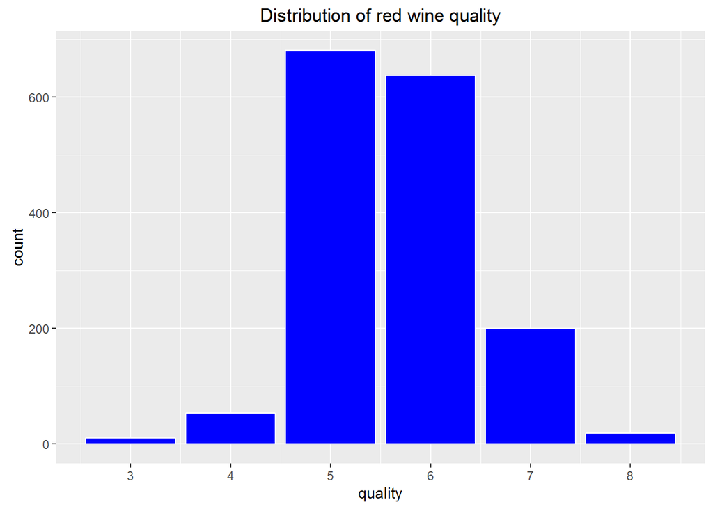

Majority of the wines have a quality rating of 5 or 6. Only a few samples have a rating of 3, 4 or 8.

Creating a new categorical variable Rating to classify the wine quality as following:

- Bad (quality 0 to 4)
- Average (quality 5-6)
- Good (quality 7-8)

```
##     Bad Average    Good
##      63    1319     217
```

There are 1319 average wines with quality rating 5-6, 217 good wines with rating 7-8 and 63 bad wines with rating 0-4

### Quality rating distribution

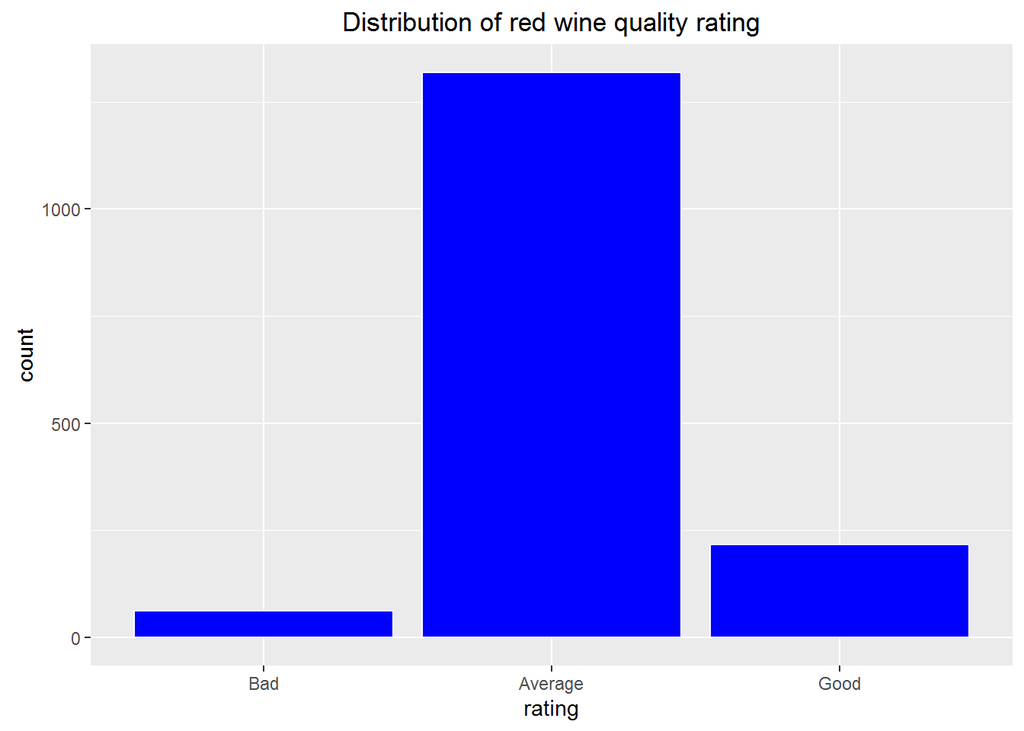

From the quality rating distribution, we see that most wines have Average quality rating. Fewer wines have good quality rating while a very few wines have bad quality rating.

## Investigating the input features

### Fixed acidity

```
##    Min. 1st Qu.  Median    Mean 3rd Qu.    Max.
##    4.60    7.10    7.90    8.32    9.20   15.90
```

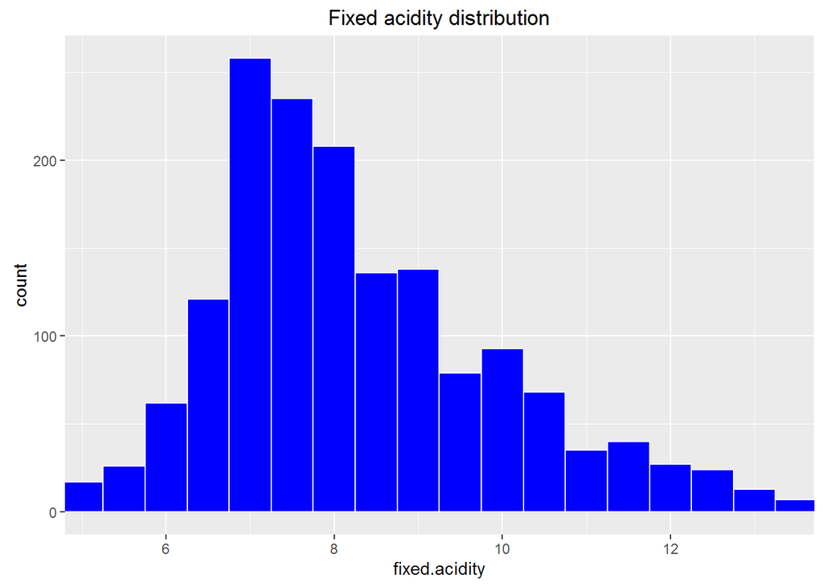

Fixed acidity has a normal distribution. A lot of the red wine samples have a fixed acidity value between 7-9.

### Volatile acidity

```
##    Min. 1st Qu.  Median    Mean 3rd Qu.    Max.
##  0.1200  0.3900  0.5200  0.5278  0.6400  1.5800
```

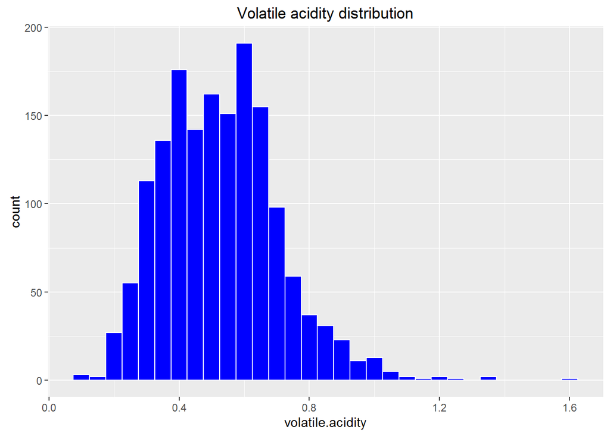

Volatile acidity seems to be slightly right skewed. I will do a log transform to see if the result would be more bell shaped.

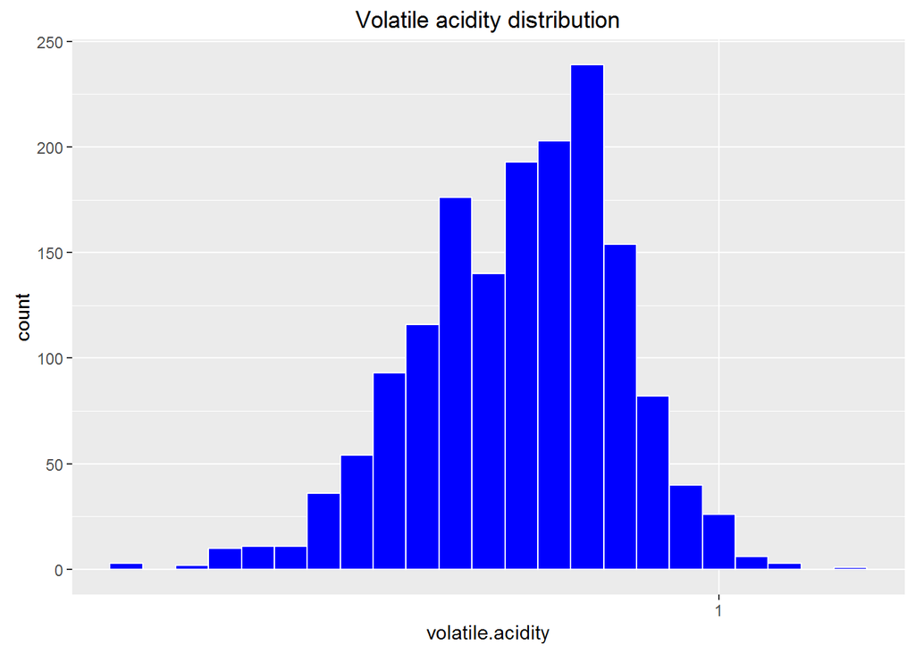

With the log transform, volatile acidity does seem to have a more bell shaped distribution.

### Citric acid

```
##    Min. 1st Qu.  Median    Mean 3rd Qu.    Max.
##   0.000   0.090   0.260   0.271   0.420   1.000
```

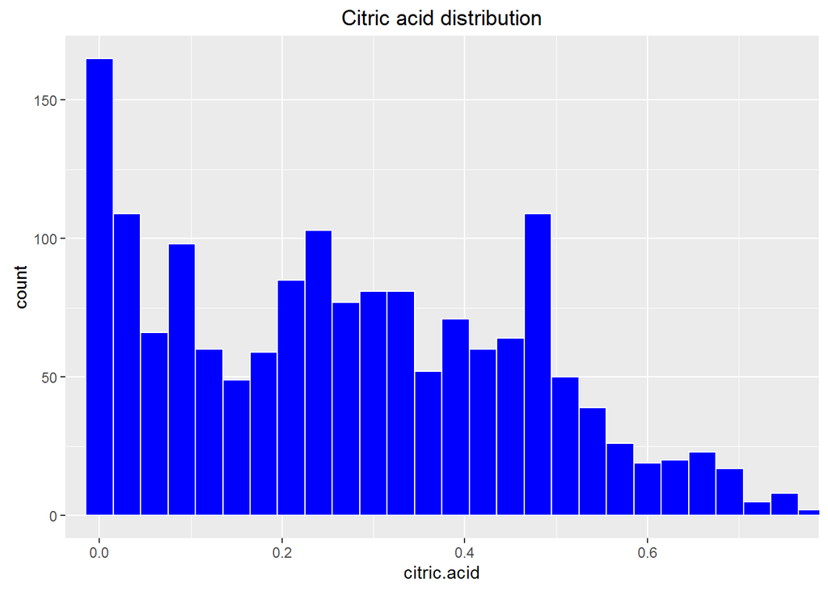

Citric acid does not seem to have any typical distribution shape.

### Residual sugar

```
##    Min. 1st Qu.  Median    Mean 3rd Qu.    Max.
##   0.900   1.900   2.200   2.539   2.600  15.500
```

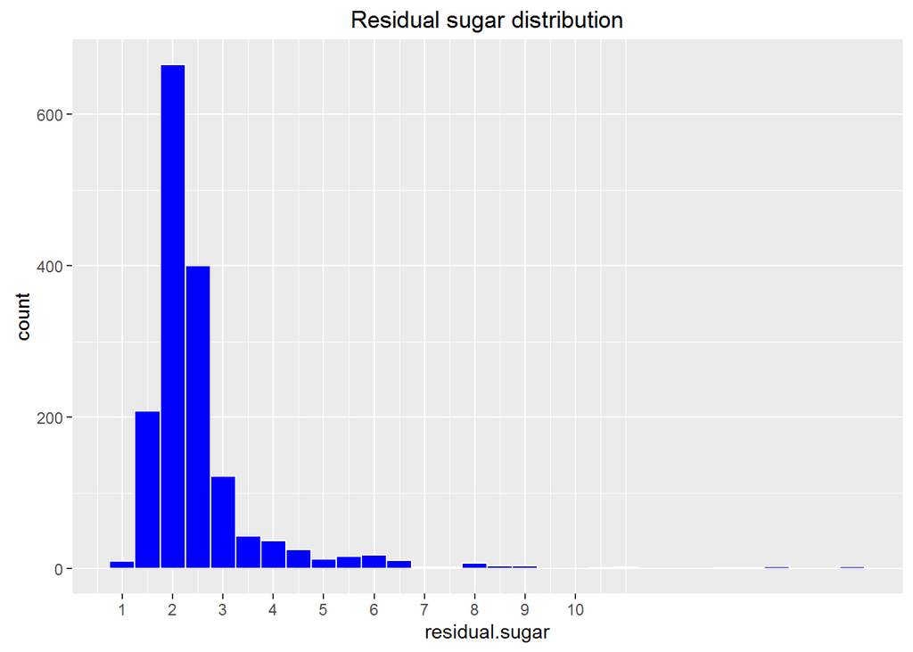

Residual sugar seems to be right skewed. Doing a log transform.

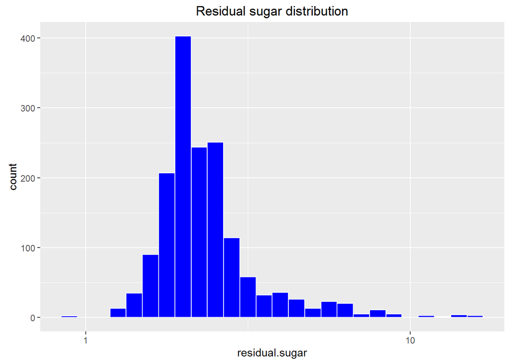

Residual sugar distribution looks more normal now after the log transform.

### Chlorides

```
##    Min. 1st Qu.  Median    Mean 3rd Qu.    Max.
## 0.01200 0.07000 0.07900 0.08747 0.09000 0.61100
```

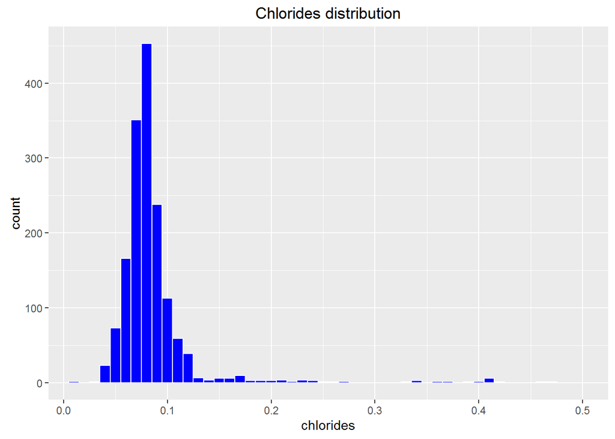

Chlorides distribution seems to be right skewed with a lot of outliers. Doing a log transform.

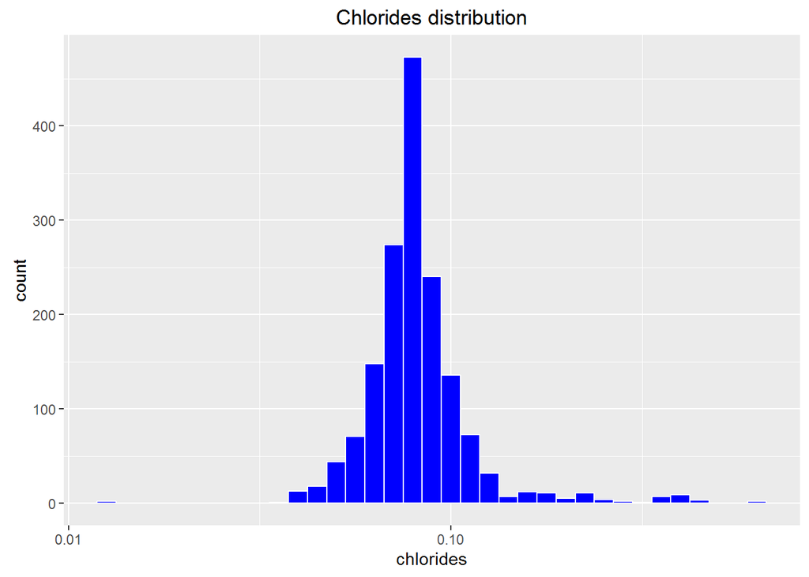

Chlorides has a normal distribution with the log transform.

### Free sulfur di oxide

```
##    Min. 1st Qu.  Median    Mean 3rd Qu.    Max.
##    1.00    7.00   14.00   15.87   21.00   72.00
```

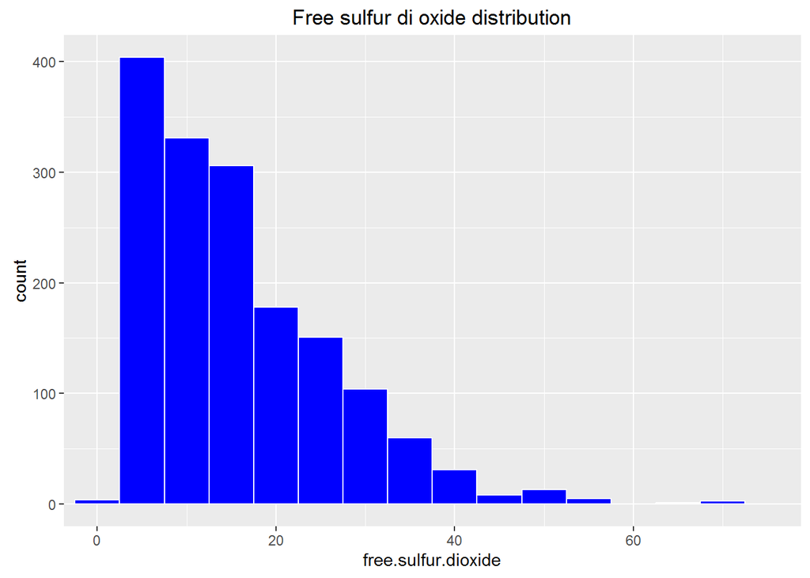

Free sulfur di oxide distribution seems to be right skewed. I am transforming the data on to a log scale.

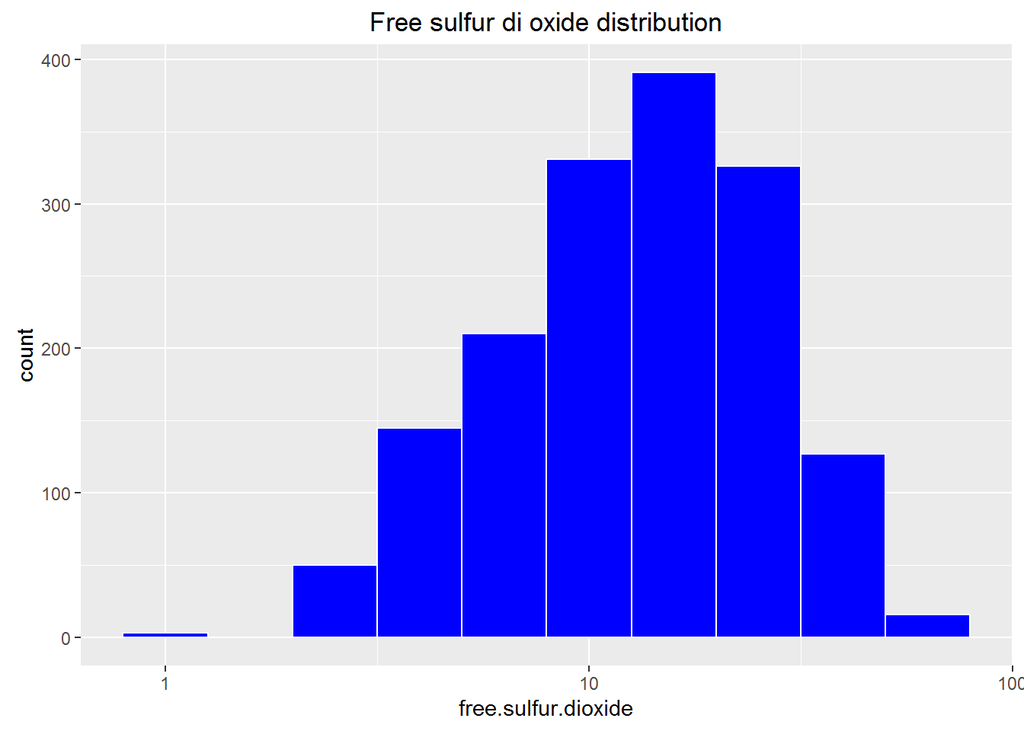

Free sulfur di oxide distribution looks more normal now on the log scale.

### Total sulfur dioxide

```
##    Min. 1st Qu.  Median    Mean 3rd Qu.    Max.
##    6.00   22.00   38.00   46.47   62.00  289.00
```

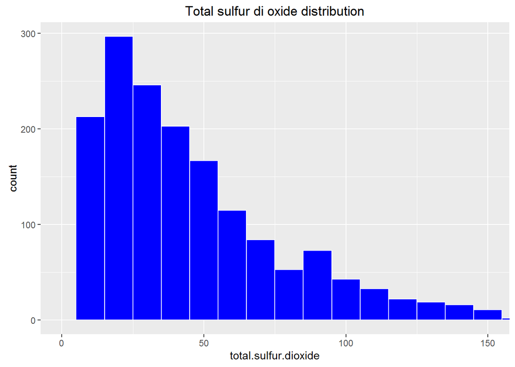

Total sulfur dioxide and Free sulfur dioxide seem to have similar distribution pattern. The histogram is right skewed. So, I am going to transform the data using a log transform.

### Total sulfur dioxide on a log scale

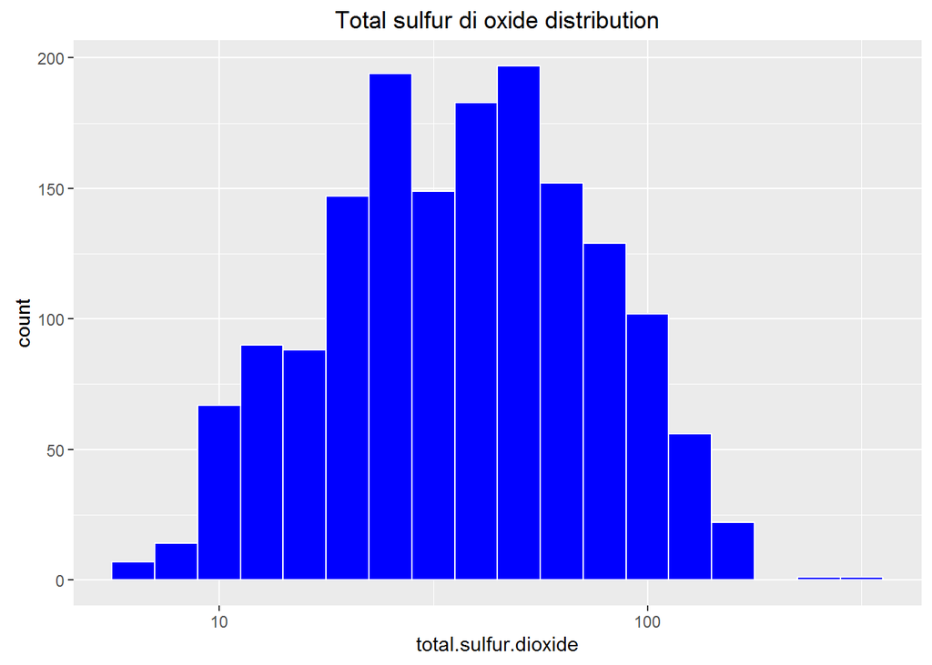

With the log transform, the histogram of Total sulfur dioxide looks more normal now.

### Density

```
##    Min. 1st Qu.  Median    Mean 3rd Qu.    Max.
##  0.9901  0.9956  0.9968  0.9967  0.9978  1.0040
```

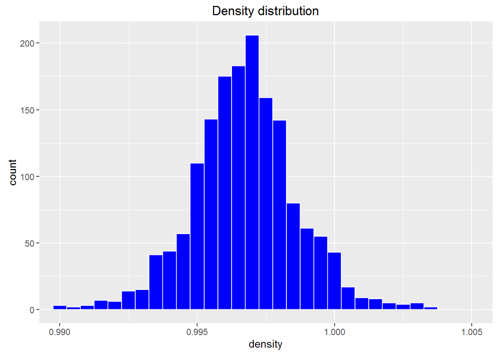

Density has a very small range from 0.99 to 1.005 and has a normal distribution.

### pH

```
##    Min. 1st Qu.  Median    Mean 3rd Qu.    Max.
##   2.740   3.210   3.310   3.311   3.400   4.010
```

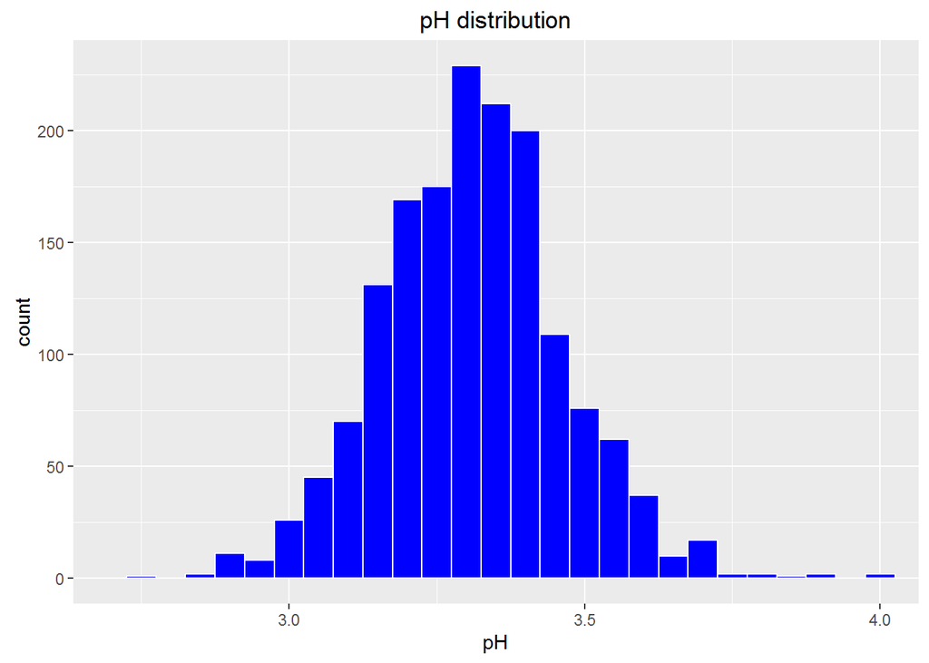

pH has a normal distribution with mean and median at 3.3

### Sulphates

```
##    Min. 1st Qu.  Median    Mean 3rd Qu.    Max.
##  0.3300  0.5500  0.6200  0.6581  0.7300  2.0000
```

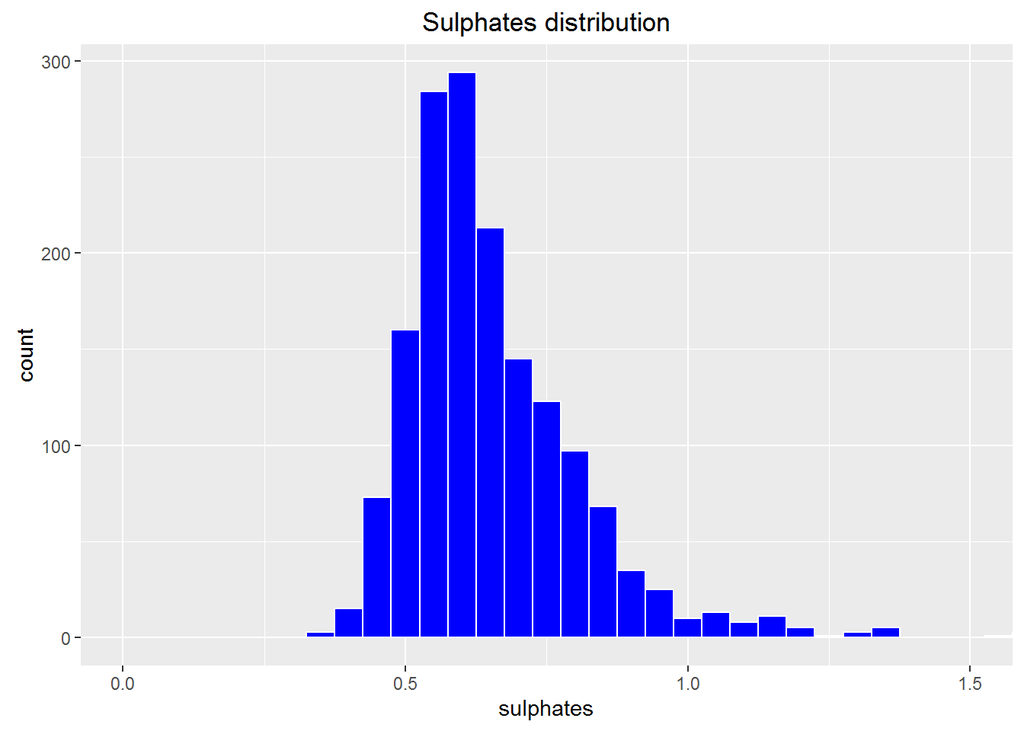

Sulphates distribution also appears to be right skewed. I am transforming the data

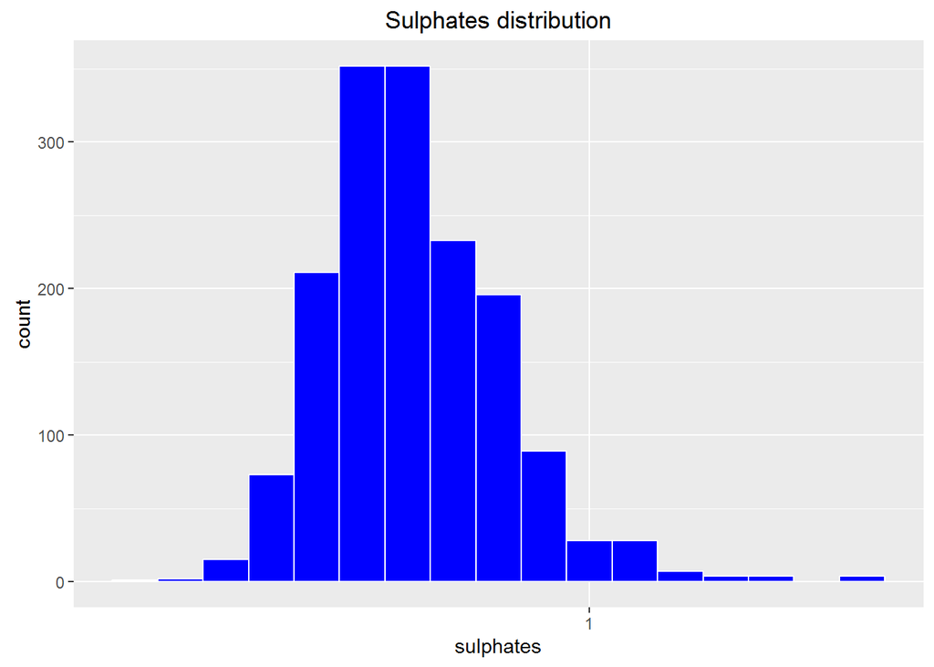

Suplhates distribution looks more normal in the log transform.

### Alcohol

```
##    Min. 1st Qu.  Median    Mean 3rd Qu.    Max.
##    8.40    9.50   10.20   10.42   11.10   14.90
```

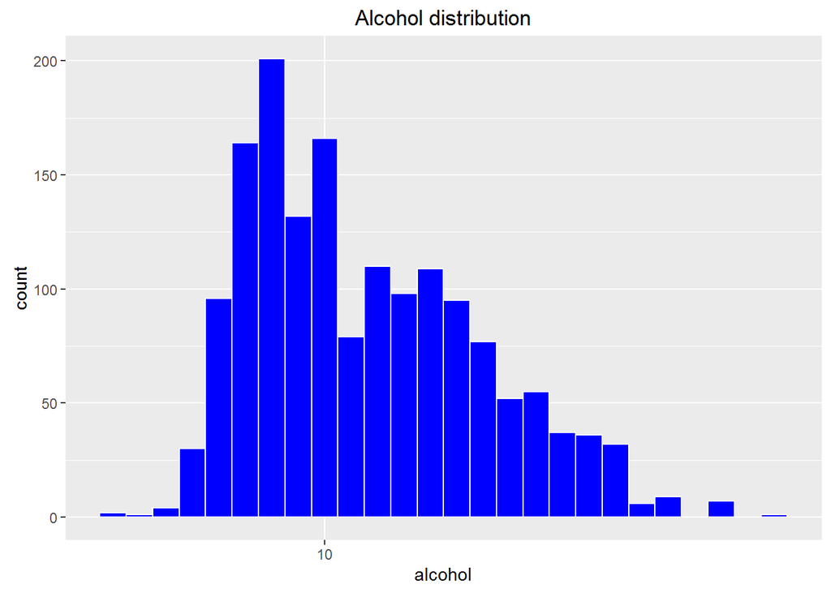

# Univariate Analysis

### What is the structure of your dataset?

The dataset has 1599 observations with 11 features/attributes and 1 output variable which is the quality of the wine.

### What is/are the main feature(s) of interest in your dataset?

The main feature of the datset is the quality of the wine. I would like to determine which of the other features in the dataset help predict the quality of wine. Some of the features I am interested in investigating are alcohol, residual.sugar, acidity. I will perform a correlation test to determine if any of these features are correlated with the wine quality.

### What other features in the dataset do you think will help support your investigation into your feature(s) of interest?

I will determine other features that might be of interest based on the results from the correlation test.

### Did you create any new variables from existing variables in the dataset?

Yes. I created a new variable - rating. Rating is a categorical variable that rates the quality of wine as good, average or bad.

- Good - quality 7-8
- Average - quality 5-6
- Bad - quality 0-4

### Of the features you investigated, were there any unusual distributions? Did you perform any operations on the data to tidy, adjust, or change the form of the data? If so, why did you do this?

Yes, there were outliers in some plots, that I removed to get a better looking plot. Also, the histogram of some of the variables was right skewed and I did a log transform and got a normal distribution.

# Bivariate Plots Section

### Analyzing correlation between input variables

```
##                      fixed.acidity volatile.acidity citric.acid
## fixed.acidity           1.00000000     -0.256130895  0.67170343
## volatile.acidity       -0.25613089      1.000000000 -0.55249568
## citric.acid             0.67170343     -0.552495685  1.00000000
## residual.sugar          0.11477672      0.001917882  0.14357716
## chlorides               0.09370519      0.061297772  0.20382291
## free.sulfur.dioxide    -0.15379419     -0.010503827 -0.06097813
## total.sulfur.dioxide   -0.11318144      0.076470005  0.03553302
## density                 0.66804729      0.022026232  0.36494718
## pH                     -0.68297819      0.234937294 -0.54190414
## sulphates               0.18300566     -0.260986685  0.31277004
## alcohol                -0.06166827     -0.202288027  0.10990325
##                      residual.sugar    chlorides free.sulfur.dioxide
## fixed.acidity           0.114776724  0.093705186        -0.153794193
## volatile.acidity        0.001917882  0.061297772        -0.010503827
## citric.acid             0.143577162  0.203822914        -0.060978129
## residual.sugar          1.000000000  0.055609535         0.187048995
## chlorides               0.055609535  1.000000000         0.005562147
## free.sulfur.dioxide     0.187048995  0.005562147         1.000000000
## total.sulfur.dioxide    0.203027882  0.047400468         0.667666450
## density                 0.355283371  0.200632327        -0.021945831
## pH                     -0.085652422 -0.265026131         0.070377499
## sulphates               0.005527121  0.371260481         0.051657572
## alcohol                 0.042075437 -0.221140545        -0.069408354
##                      total.sulfur.dioxide     density          pH
## fixed.acidity                 -0.11318144  0.66804729 -0.68297819
## volatile.acidity               0.07647000  0.02202623  0.23493729
## citric.acid                    0.03553302  0.36494718 -0.54190414
## residual.sugar                 0.20302788  0.35528337 -0.08565242
## chlorides                      0.04740047  0.20063233 -0.26502613
## free.sulfur.dioxide            0.66766645 -0.02194583  0.07037750
## total.sulfur.dioxide           1.00000000  0.07126948 -0.06649456
## density                        0.07126948  1.00000000 -0.34169933
## pH                            -0.06649456 -0.34169933  1.00000000
## sulphates                      0.04294684  0.14850641 -0.19664760
## alcohol                       -0.20565394 -0.49617977  0.20563251
##                         sulphates     alcohol
## fixed.acidity         0.183005664 -0.06166827
## volatile.acidity     -0.260986685 -0.20228803
## citric.acid           0.312770044  0.10990325
## residual.sugar        0.005527121  0.04207544
## chlorides             0.371260481 -0.22114054
## free.sulfur.dioxide   0.051657572 -0.06940835
## total.sulfur.dioxide  0.042946836 -0.20565394
## density               0.148506412 -0.49617977
## pH                   -0.196647602  0.20563251
## sulphates             1.000000000  0.09359475
## alcohol               0.093594750  1.00000000
```

### Correlation plot

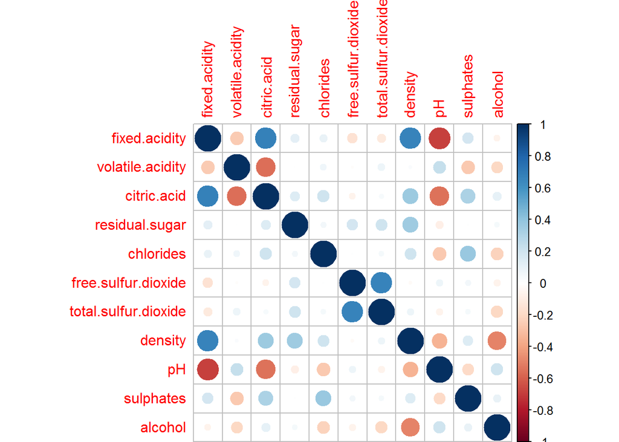

From the correlation matrix and plot of the input variables, we observe the following relationships between the variables.

- Positive correlation between fixed.acidity and citric.acid
- Positive correlation between fixed.acidity and density
- Positive correlation between free.sulfur.dioxide and total.sulfur.dioxide
- Negative correlation between pH and fixed.acidity
- Negatie correlation between pH and citric.acid
- Negative correlation between alcohol and density

### fixed.acidity and density

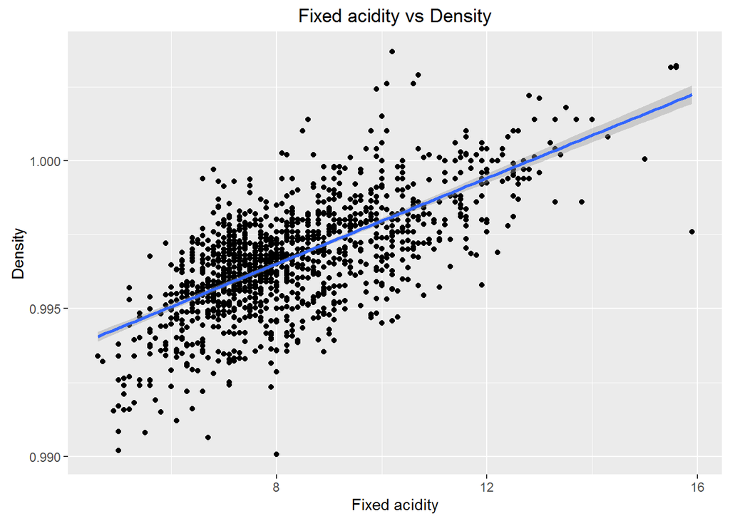

Fixed acidity is postively correlated with density with a correlation coefficient of 0.668

### alcohol and density

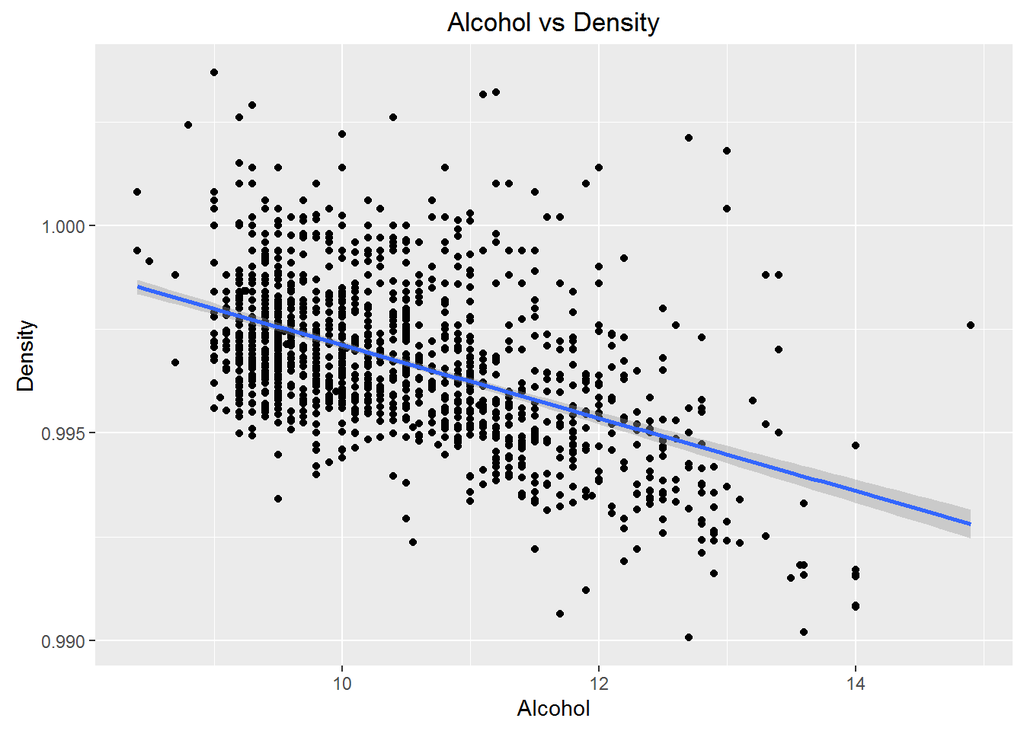

Alcohol and density are negatively correlated with a correlation coeffienct of -0.496. Wines with higher alcohol % have lower density and vice versa.

### pH and fixed.acidity

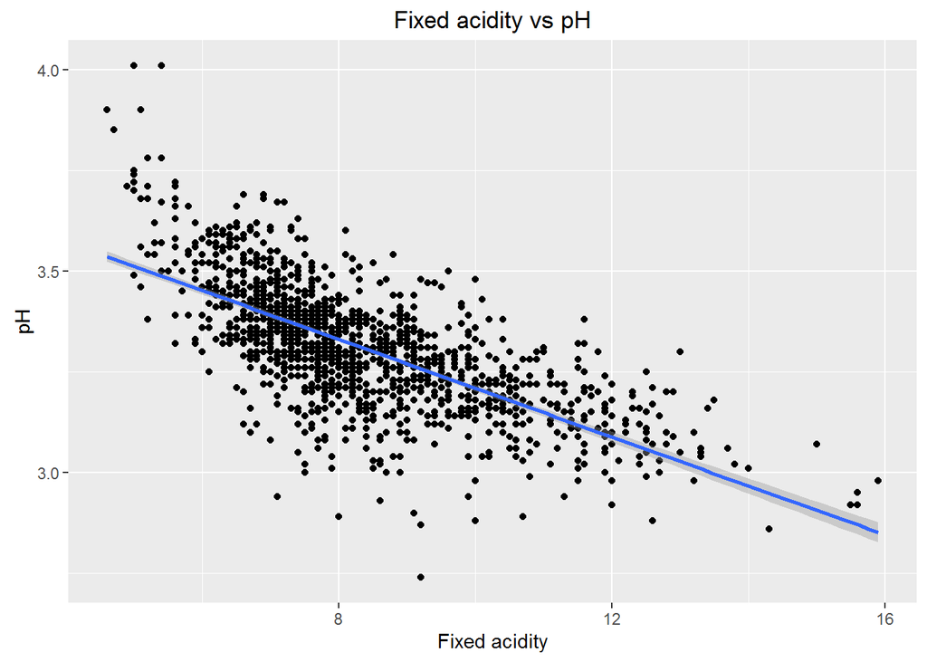

pH and Fixed acidity are negatively correlated with a correlation coeffienct of -0.682.

### pH and citric.acid

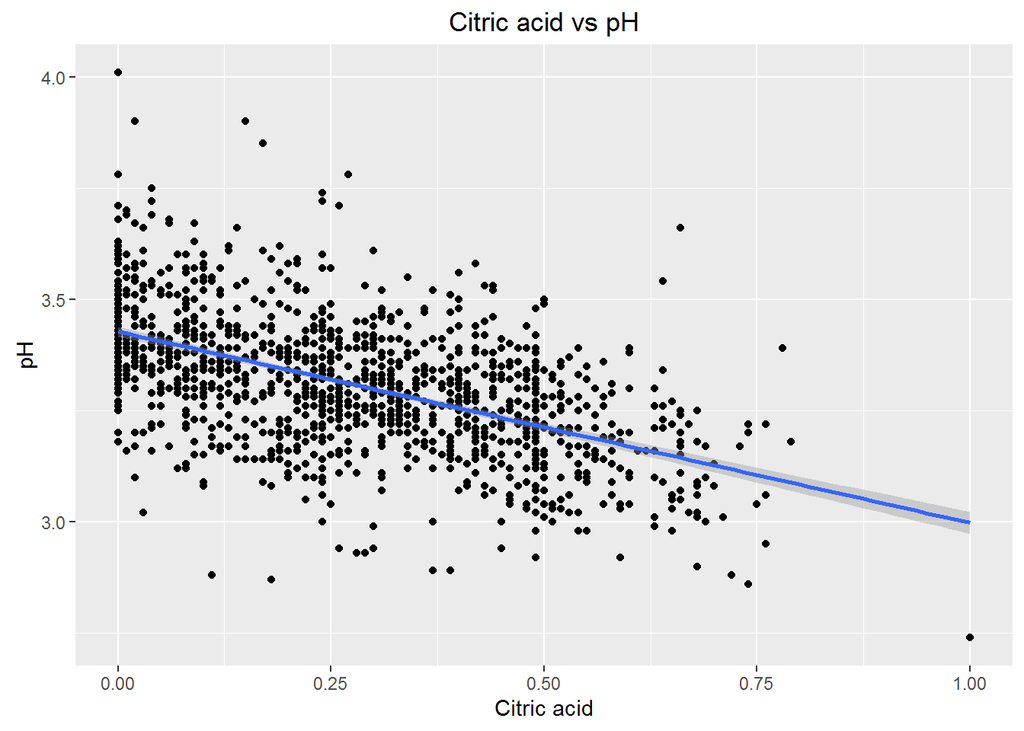

pH and Citric acid are negatively correlated with a correlation coeffienct of -0.541.

### Analyzing correlation between input variables and Quality

```
##                             [,1]
## fixed.acidity         0.12405165
## volatile.acidity     -0.39055778
## citric.acid           0.22637251
## residual.sugar        0.01373164
## chlorides            -0.12890656
## free.sulfur.dioxide  -0.05065606
## total.sulfur.dioxide -0.18510029
## density              -0.17491923
## pH                   -0.05773139
## sulphates             0.25139708
## alcohol               0.47616632
```

From the correlation values, we can see that the features which have the highest correlation with wine quality are alcohol, volatile acidity, citric acid, sulphates. Let’s analyze these.

### Alcohol and Quality rating

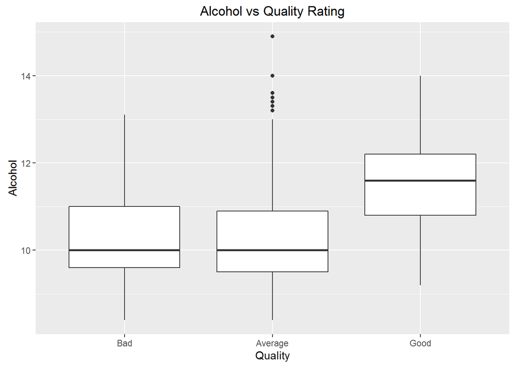

```
## redwine$rating: Bad
##    Min. 1st Qu.  Median    Mean 3rd Qu.    Max.
##    8.40    9.60   10.00   10.22   11.00   13.10
## --------------------------------------------------------
## redwine$rating: Average
##    Min. 1st Qu.  Median    Mean 3rd Qu.    Max.
##    8.40    9.50   10.00   10.25   10.90   14.90
## --------------------------------------------------------
## redwine$rating: Good
##    Min. 1st Qu.  Median    Mean 3rd Qu.    Max.
##    9.20   10.80   11.60   11.52   12.20   14.00
```

There is a significiant difference in alcohol value between “Good” quality wine and others. Good quality wines have a higher alcohol value. “Average” and “Bad” quality wines have a lower alcohol values and a similar alcohol distribution.

### Volatile acidity and Quality rating

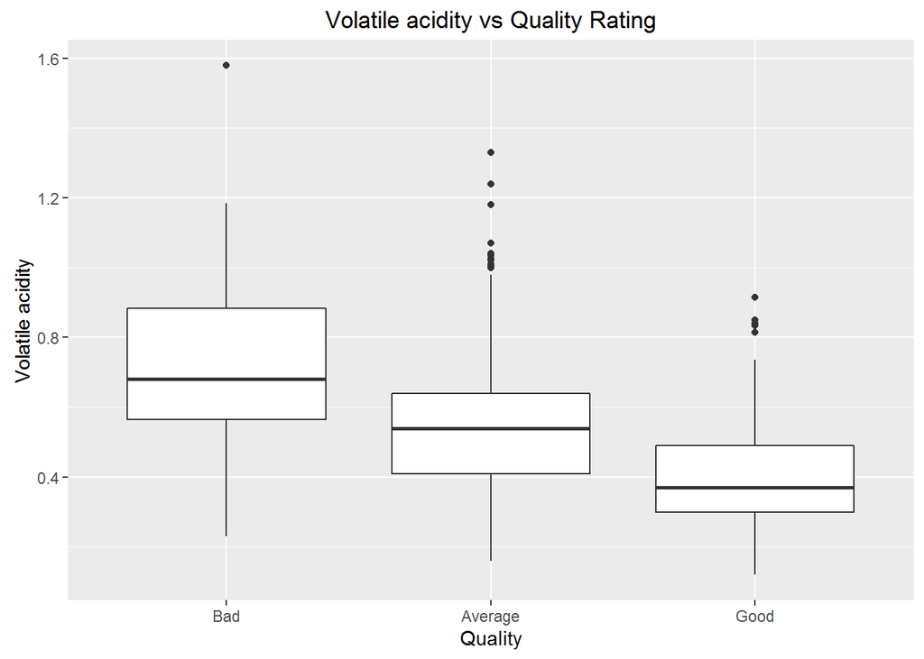

```
## redwine$rating: Bad
##    Min. 1st Qu.  Median    Mean 3rd Qu.    Max.
##  0.2300  0.5650  0.6800  0.7242  0.8825  1.5800
## --------------------------------------------------------
## redwine$rating: Average
##    Min. 1st Qu.  Median    Mean 3rd Qu.    Max.
##  0.1600  0.4100  0.5400  0.5386  0.6400  1.3300
## --------------------------------------------------------
## redwine$rating: Good
##    Min. 1st Qu.  Median    Mean 3rd Qu.    Max.
##  0.1200  0.3000  0.3700  0.4055  0.4900  0.9150
```

There is a significant difference in volatile acidity between Good quality wine and others. Good quality wines have a lower volatile acidity values. Higher the volatile acidity values, lower the quality of the wine.

Let us also look into the voltile acidity vs the actual quality values of the wines.

### Volatile acidity and Quality

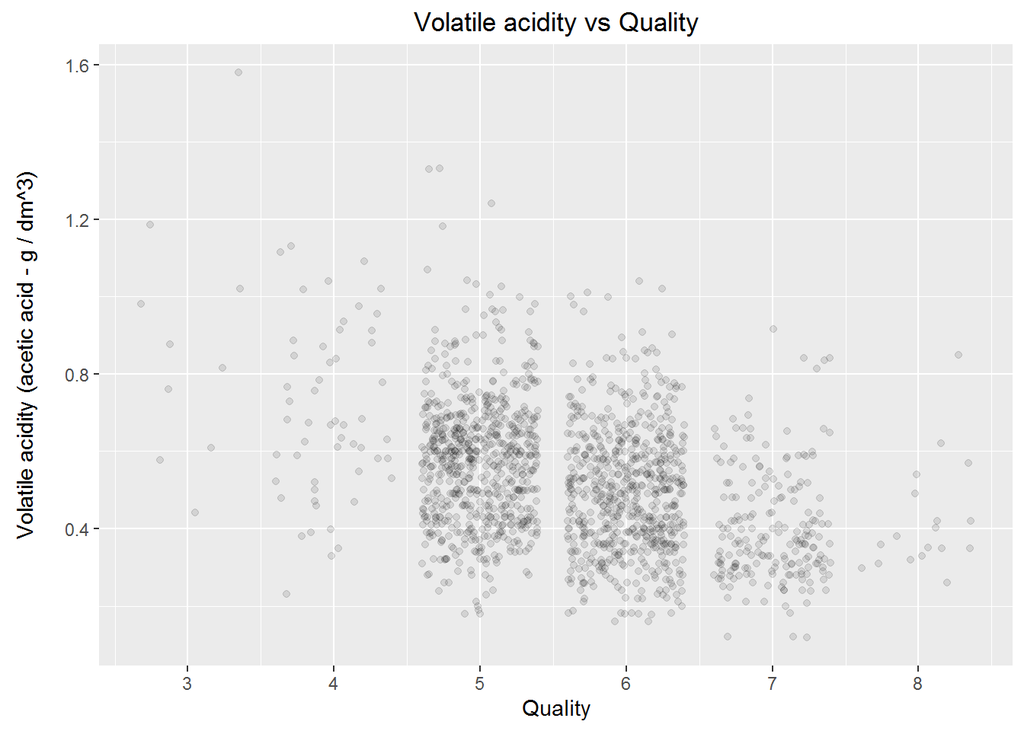

We notice a similar trend with higher quality red wines having lower values of volatile acidity.

### Citric acid and Quality rating

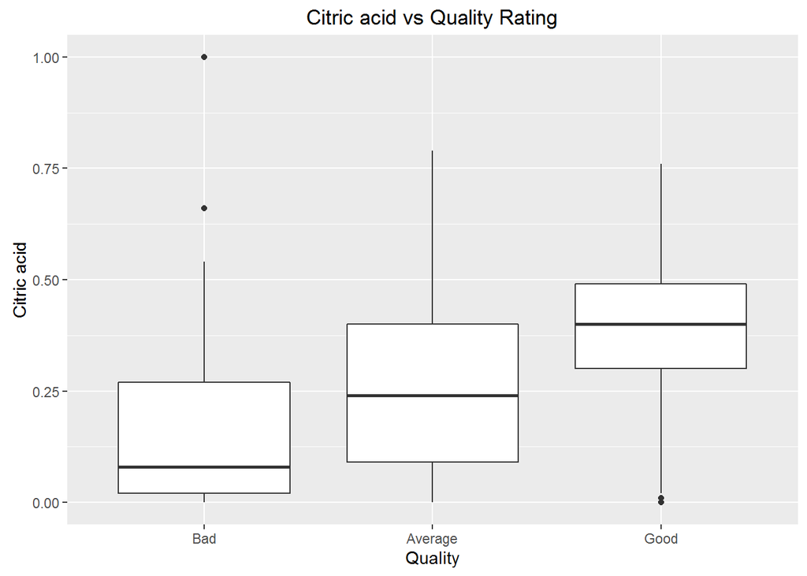

```
## redwine$rating: Bad
##    Min. 1st Qu.  Median    Mean 3rd Qu.    Max.
##  0.0000  0.0200  0.0800  0.1737  0.2700  1.0000
## --------------------------------------------------------
## redwine$rating: Average
##    Min. 1st Qu.  Median    Mean 3rd Qu.    Max.
##  0.0000  0.0900  0.2400  0.2583  0.4000  0.7900
## --------------------------------------------------------
## redwine$rating: Good
##    Min. 1st Qu.  Median    Mean 3rd Qu.    Max.
##  0.0000  0.3000  0.4000  0.3765  0.4900  0.7600
```

Good quality wines seem to have a higher value of citric acid than average/bad ones.

### Sulphates and Quality rating

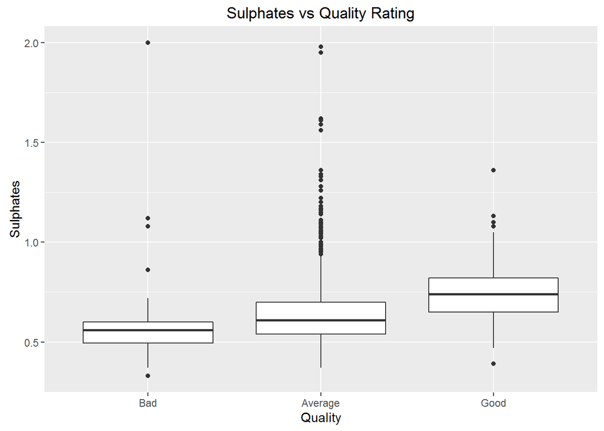

```
## redwine$rating: Bad
##    Min. 1st Qu.  Median    Mean 3rd Qu.    Max.
##  0.3300  0.4950  0.5600  0.5922  0.6000  2.0000
## --------------------------------------------------------
## redwine$rating: Average
##    Min. 1st Qu.  Median    Mean 3rd Qu.    Max.
##  0.3700  0.5400  0.6100  0.6473  0.7000  1.9800
## --------------------------------------------------------
## redwine$rating: Good
##    Min. 1st Qu.  Median    Mean 3rd Qu.    Max.
##  0.3900  0.6500  0.7400  0.7435  0.8200  1.3600
```

Good quality wines have a slightly higher value of sulphates than average/bad ones.

### Residual sugar and Quality Rating

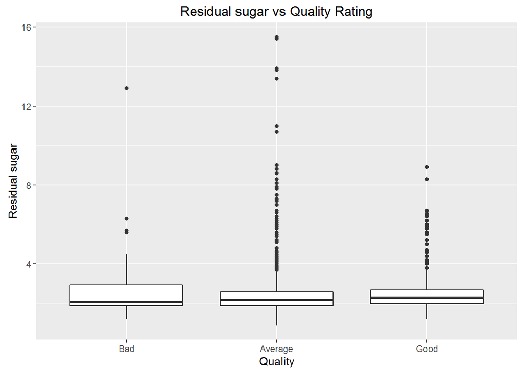

Log Transforming the plot to look at the medians clearly

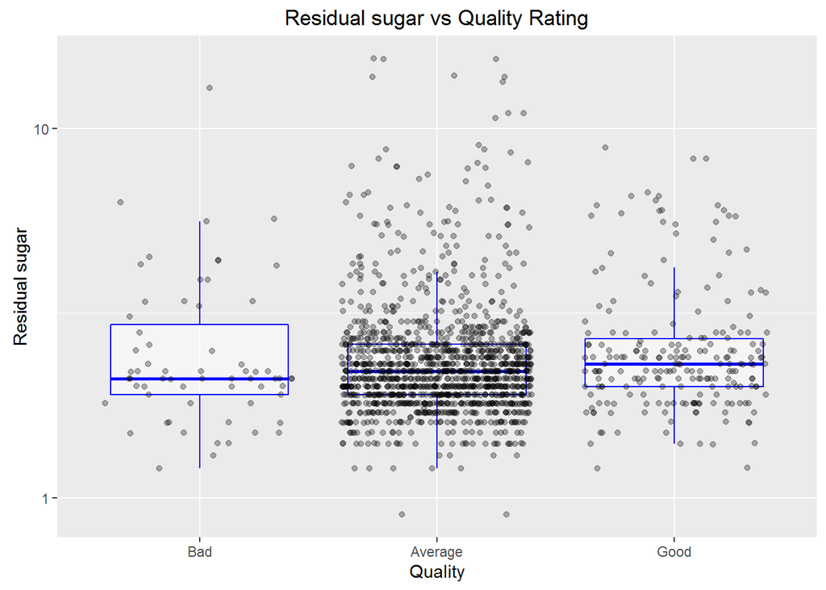

It seems residual sugar has no correaltion with quality of the wine. Although I thought, sugar might have some influence on the wine quality, it looks like all quality wines have about the same amount of residual sugar.

# Bivariate Analysis

### Talk about some of the relationships you observed in this part of the investigation.

Wine quality correlates with alochol, volatile acidity, citric acid, sulphates. Some of the relations I have observed are:

- Good quality wines have lower volatile acidity than average/bad quality ones
- Good quality wines have higher citric acid than average/bad quality ones
- Good quality wines have higher alcohol than average/bad quality ones
- Good quality wines have a slightly higher value of sulphates than average/bad ones.

### What was the strongest relationship you found?

The strongest relationshp is between quality and volatile acidity and quality and alcohol.